# Final Project- Ramineni Gautam Kumar

#### **Problem Statement**

###### **A big part of customer relationship management involves efforts to retain existing customers. This is because in many cases the costs incurred to attract new customers are much larger than the costs to retain the existing customers. As part of the class project, your goal is to analyze customer data of a telecommunications company and identify the ones that are likely to leave so that you can take some action to retain them by offering incentives. The data is spread over two .rda files, Model_Building_Data and Implementation_Data. Model_Building_Data should be used to build the model. It contains current customers as well as customers who have left. The description of the columns in this dataset is below:**

```r
load("Model_Building_Data.rda") #Loading the data
head(Model_Building_Data) #Previewing data
```

|  | Gender | SeniorCitizen | Partner | Dependents | Tenure | PhoneService | MultipleLines | InternetService | OnlineSecurity | DeviceProtection | StreamingMovies | Contract | PaperlessBilling | PaymentMethod | MonthlyCharges | TotalCharges | Status |
| --- | --- | --- | --- | --- | --- | --- | --- | --- | --- | --- | --- | --- | --- | --- | --- | --- | --- |
| 1 | Female | 0 | Yes | No | 1 | No | No phone service | DSL | No | No | No | Month-to-month | Yes | Electronic check | 29.85 | 29.85 | Current |
| 2 | Male | 0 | No | No | 34 | Yes | No | DSL | Yes | Yes | No | One year | No | Mailed check | 56.95 | 1889.50 | Current |
| 3 | Male | 0 | No | No | 2 | Yes | No | DSL | Yes | No | No | Month-to-month | Yes | Mailed check | 53.85 | 108.15 | Left |
| 4 | Male | 0 | No | No | 45 | No | No phone service | DSL | Yes | Yes | No | One year | No | Bank transfer (automatic) | 42.30 | 1840.75 | Current |
| 5 | Female | 0 | No | No | 2 | Yes | No | Fiber optic | No | No | No | Month-to-month | Yes | Electronic check | 70.70 | 151.65 | Left |
| 6 | Female | 0 | No | No | 8 | Yes | Yes | Fiber optic | No | Yes | Yes | Month-to-month | Yes | Electronic check | 99.65 | 820.50 | Left |

#### **Question 1:**

##### **Data preparation and Exploratory Data Analysis**

###### **Start with the Model_Building_Data file and follow concepts learnt in Week 2 to clean the data (the other data file will be used in part 8). If there are missing values then indicate how you plan to work with them.**

```r
colSums(is.na(Model_Building_Data))
```

```
          Gender    SeniorCitizen          Partner       Dependents           Tenure     PhoneService    MultipleLines  InternetService   OnlineSecurity
               0                0                0                0                0                0                0                0                0
DeviceProtection  StreamingMovies         Contract PaperlessBilling    PaymentMethod   MonthlyCharges     TotalCharges           Status
               0                0                0                0                0                0               11                0
```

###### There are 11 missing values in the TotalCharges column. I will replace them with the median to keep the data balanced.

```r
library(dplyr)

# Check for missing values before imputation
cat("Missing values before imputation:\n")
```

```
Missing values before imputation:
```

```r
print(colSums(is.na(Model_Building_Data)))
```

```
          Gender    SeniorCitizen          Partner       Dependents           Tenure     PhoneService    MultipleLines  InternetService   OnlineSecurity
               0                0                0                0                0                0                0                0                0
DeviceProtection  StreamingMovies         Contract PaperlessBilling    PaymentMethod   MonthlyCharges     TotalCharges           Status
               0                0                0                0                0                0               11                0
```

```r
# Impute missing TotalCharges with the median
Model_Building_Data <- Model_Building_Data %>%
  mutate(TotalCharges = ifelse(is.na(TotalCharges),
                               median(TotalCharges, na.rm = TRUE),
                               TotalCharges))

# Confirm that missing values are handled
cat("\nMissing values after imputing TotalCharges:\n")
```

```
Missing values after imputing TotalCharges:
```

```r
print(colSums(is.na(Model_Building_Data)))
```

```
          Gender    SeniorCitizen          Partner       Dependents           Tenure     PhoneService    MultipleLines  InternetService   OnlineSecurity
               0                0                0                0                0                0                0                0                0
DeviceProtection  StreamingMovies         Contract PaperlessBilling    PaymentMethod   MonthlyCharges     TotalCharges           Status
               0                0                0                0                0                0                0                0
```

###### **Explore the dataset and use data visualization to describe underlying trends. Record your observations on the distributions of each variable.**

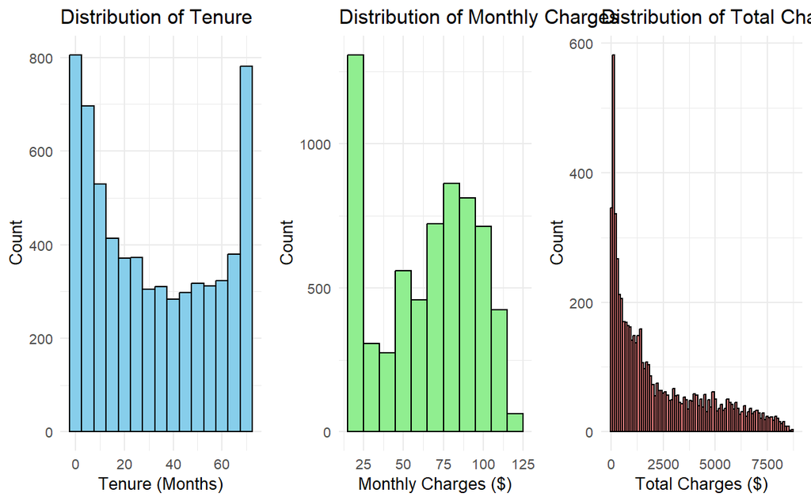

```r
library(ggplot2)
library(gridExtra)

# Plot for Tenure
p1 <- ggplot(Model_Building_Data, aes(x = Tenure)) +
  geom_histogram(binwidth = 5, fill = "skyblue", color = "black") +
  labs(title = "Distribution of Tenure", x = "Tenure (Months)", y = "Count") +
  theme_minimal()

# Plot for Monthly Charges
p2 <- ggplot(Model_Building_Data, aes(x = MonthlyCharges)) +
  geom_histogram(binwidth = 10, fill = "lightgreen", color = "black") +
  labs(title = "Distribution of Monthly Charges", x = "Monthly Charges ($)", y = "Count") +
  theme_minimal()

# Plot for Total Charges
p3 <- ggplot(Model_Building_Data, aes(x = TotalCharges)) +
  geom_histogram(binwidth = 100, fill = "lightcoral", color = "black") +
  labs(title = "Distribution of Total Charges", x = "Total Charges ($)", y = "Count") +
  theme_minimal()

# Arrange the three plots side by side
grid.arrange(p1, p2, p3, nrow = 1)
```

```r
summary(Model_Building_Data[c("Tenure","MonthlyCharges","TotalCharges")])
```

```
     Tenure      MonthlyCharges    TotalCharges
 Min.   : 0.00   Min.   : 18.25   Min.   :  18.8
 1st Qu.: 9.00   1st Qu.: 35.20   1st Qu.: 398.6
 Median :29.00   Median : 70.35   Median :1389.7
 Mean   :32.26   Mean   : 64.66   Mean   :2272.0
 3rd Qu.:55.00   3rd Qu.: 89.85   3rd Qu.:3770.8
 Max.   :72.00   Max.   :118.75   Max.   :8684.8
```

###### **• Total Charges:**

###### Only a few customers have very high total charges. As total charges go up, the number of customers goes down. This means that only a small number of people have stayed long enough to pay a lot overall.

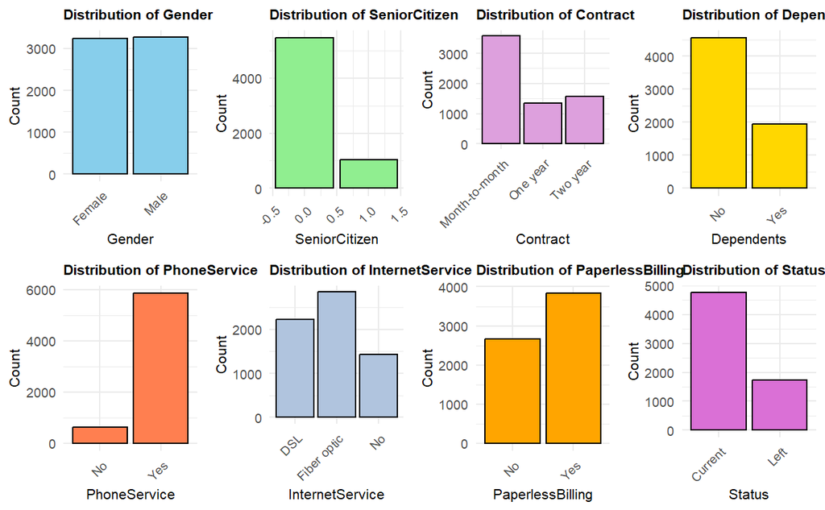

```r
library(ggplot2)
library(gridExtra)

# List of selected categorical columns to plot
cat_columns <- c("Gender", "SeniorCitizen", "Contract", "Dependents",
                 "PhoneService", "InternetService", "PaperlessBilling", "Status")

# Custom colors for each plot (repeat or expand as needed)
custom_colors <- c("skyblue", "lightgreen", "plum", "gold",
                   "coral", "lightsteelblue", "orange", "orchid")

# Function to create bar plots for each categorical variable
create_count_plots <- function(data, cat_columns, colors) {
  plots <- list()
  for (i in seq_along(cat_columns)) {
    col <- cat_columns[i]
    plot <- ggplot(data, aes(x = .data[[col]])) +
      geom_bar(fill = colors[i], color = "black") +
      labs(title = paste("Distribution of", col),
           x = col,
           y = "Count") +
      theme_minimal() +
      theme(
        axis.text.x = element_text(size = 8, angle = 45, hjust = 1),
        axis.text.y = element_text(size = 8),
        axis.title.x = element_text(size = 9),
        axis.title.y = element_text(size = 9),
        plot.title = element_text(size = 9, face = "bold")
      )
    plots[[i]] <- plot
  }
  return(plots)
}

# Generate plots with custom colors
plots <- create_count_plots(Model_Building_Data, cat_columns, custom_colors)

# Arrange the plots in 2 rows
grid.arrange(grobs = plots, nrow = 2)
```

###### **• Gender:** There are almost the same number of male and female customers, so the data is balanced in terms of gender.

###### **• Senior Citizen:** Most customers are not senior citizens, and only a small number are.

###### **• Contract:** Most people use month-to-month contracts. Fewer have one-year or two-year contracts. This might mean that month-to-month customers are more likely to leave.

###### **• Dependents:** Most customers don’t have dependents, while some do.

###### **• Phone Service:** Almost all customers have phone service. Only a few do not.

###### **• Internet Service:** Fiber optic is the most used internet type, followed by DSL. Some customers don’t have internet service at all.

###### **• Paperless Billing**: More people choose paperless billing instead of getting printed bills.

###### **• Status:** Most customers are still with the company (“Current”), while a smaller group has left, showing customer churn.

###### **Report your detailed observations of any apparent relationship between customer status and each independent variable.**

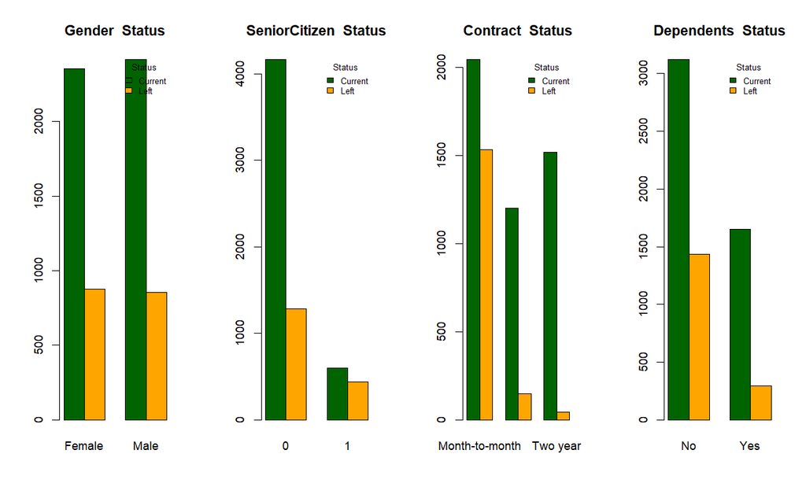

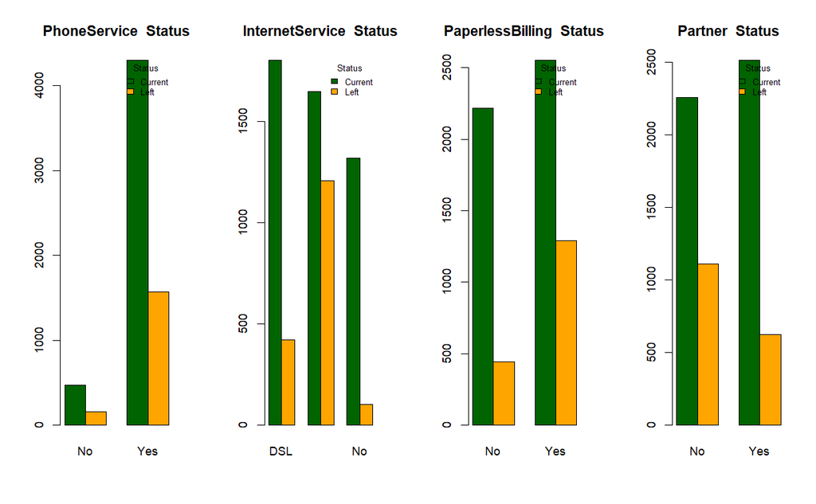

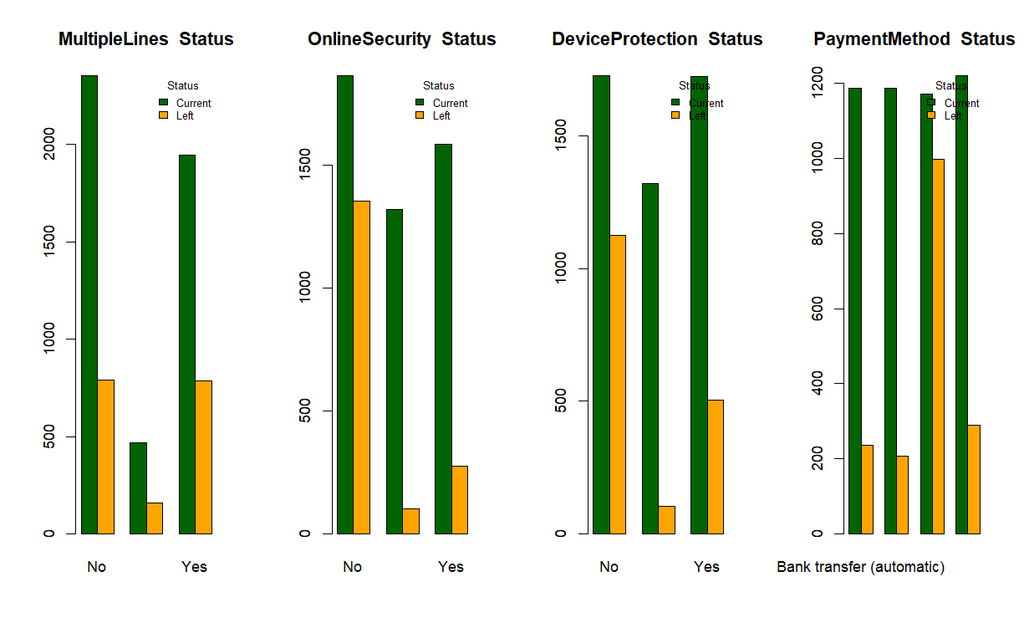

```r
# Define a new color scheme for the statuses
status_colors <- c("darkgreen", "orange")

qual_Variables <-  c("Gender", "SeniorCitizen", "Contract", "Dependents", "PhoneService", "InternetService", "PaperlessBilling","Partner","MultipleLines","OnlineSecurity","DeviceProtection","PaymentMethod")

# Set up a grid layout for 1 rows and 4 columns of plots
par(mfrow=c(1, 4))

# Loop through the selected categorical columns and create bar plots for each
for (col in qual_Variables) {
  # Create a contingency table for 'Status' and the categorical variable
  contingency_table <- table(Model_Building_Data$Status, Model_Building_Data[[col]])

  # Create a bar plot with the new color scheme
  barplot(contingency_table, main=paste(col, " Status"),
          col=status_colors, beside=TRUE)  # 'beside=TRUE' for side-by-side bars

  # Add a legend with the status labels and the new colors
  legend("topright", legend=rownames(contingency_table), fill=status_colors, cex=0.7,
         bty="n", title="Status")
}
```

###### **• Online Security:** Customers who don’t have online security leave more often. People with online security tend to stay.

###### **• Device Protection:** More customers without device protection leave. Those with it are more likely to remain customers.

###### **• Payment Method (Bank Transfer):** People who use automatic bank transfers are more likely to stay than leave.

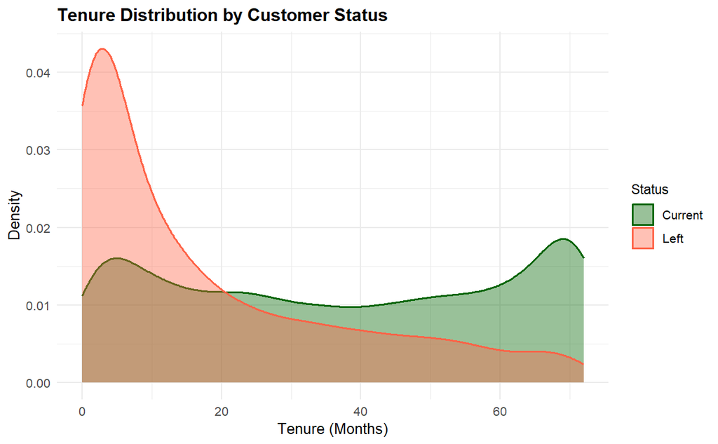

```r
library(ggplot2)

ggplot(Model_Building_Data, aes(x = Tenure, fill = Status, color = Status)) +
  geom_density(alpha = 0.4, size = 0.8) +
  labs(
    title = "Tenure Distribution by Customer Status",
    x = "Tenure (Months)",
    y = "Density"
  ) +
  theme_minimal() +
  theme(
    plot.title = element_text(size = 13, face = "bold"),
    axis.title = element_text(size = 11),
    legend.title = element_text(size = 10),
    legend.position = "right"
  ) +
  scale_fill_manual(values = c("Current" = "darkgreen", "Left" = "tomato")) +
  scale_color_manual(values = c("Current" = "darkgreen", "Left" = "tomato"))
```

###### Customers who have been with the company for less than 10 months are more likely to leave. The longer a customer stays, the less likely they are to leave. Most current customers have stayed for a long time, especially beyond 60 months.

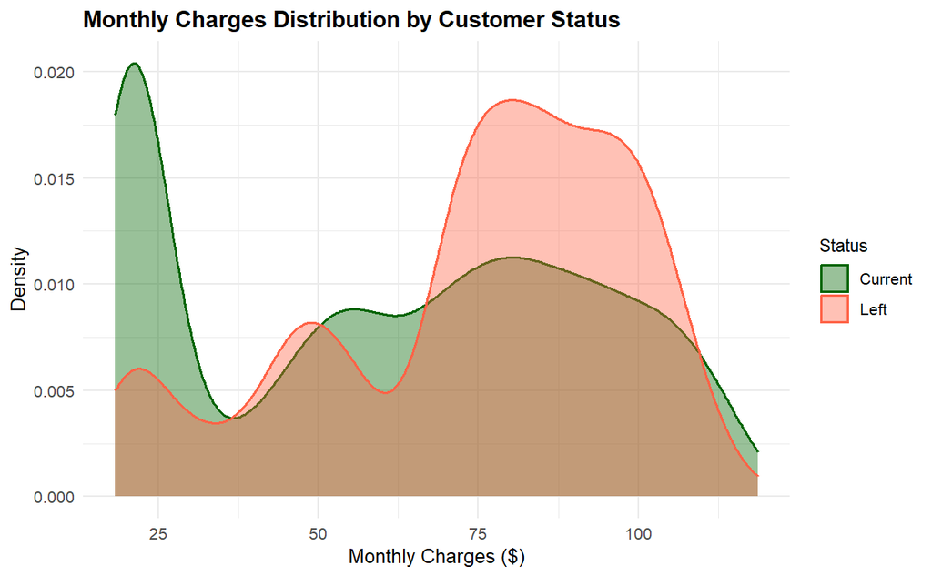

```r
library(ggplot2)

ggplot(Model_Building_Data, aes(x = MonthlyCharges, fill = Status, color = Status)) +
  geom_density(alpha = 0.4, size = 0.8) +
  labs(
    title = "Monthly Charges Distribution by Customer Status",
    x = "Monthly Charges ($)",
    y = "Density"
  ) +
  theme_minimal() +
  theme(
    plot.title = element_text(size = 13, face = "bold"),
    axis.title = element_text(size = 11),
    legend.title = element_text(size = 10),
    legend.position = "right"
  ) +
  scale_fill_manual(values = c("Current" = "darkgreen", "Left" = "tomato")) +
  scale_color_manual(values = c("Current" = "darkgreen", "Left" = "tomato"))
```

###### Customers who pay lower monthly charges (around $20–$30) are more likely to stay. Those who pay more (around $70–$100) are more likely to leave. Churn happens at all charge levels, but it becomes more common as the monthly charges go up.

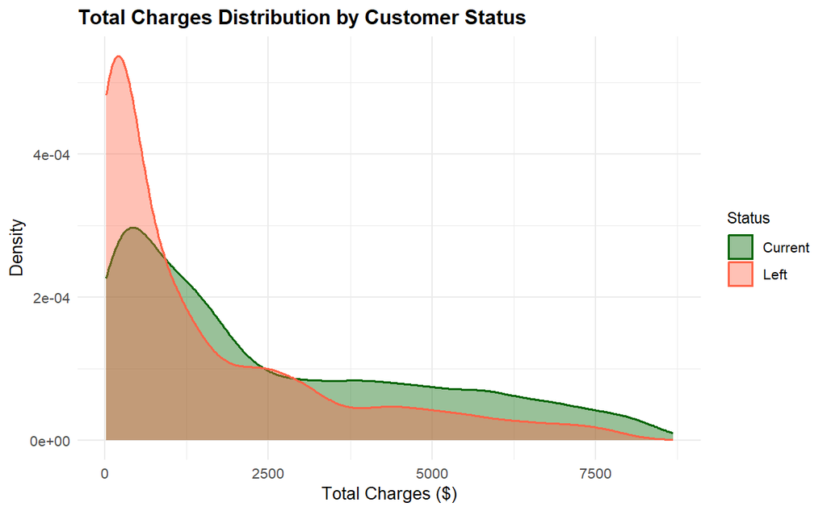

```r
library(ggplot2)

ggplot(Model_Building_Data, aes(x = TotalCharges, fill = Status, color = Status)) +
  geom_density(alpha = 0.4, size = 0.8) +
  labs(
    title = "Total Charges Distribution by Customer Status",
    x = "Total Charges ($)",
    y = "Density"
  ) +
  theme_minimal() +
  theme(
    plot.title = element_text(size = 13, face = "bold"),
    axis.title = element_text(size = 11),
    legend.title = element_text(size = 10),
    legend.position = "right"
  ) +
  scale_fill_manual(values = c("Current" = "darkgreen", "Left" = "tomato")) +
  scale_color_manual(values = c("Current" = "darkgreen", "Left" = "tomato"))
```

###### Customers with lower total charges are more likely to leave. As total charges increase, the number of customers leaving goes down, while more long-term (current) customers have higher total charges

###### **Create any new columns if you need to at this point.**

```r
library(dplyr)
Model_Building_Data <- Model_Building_Data %>%
  mutate(SeniorCitizen = as.factor(SeniorCitizen)) %>%
  mutate(Status = as.factor(Status))
```

###### **Once you are done with the above, split the data set randomly into a training set (80%) and a test set (20%).**

```r
set.seed(400)
num_rows <- nrow(Model_Building_Data)

# Create a logical vector for training indices
train_indices <- sample(seq_len(num_rows), size = 0.8 * num_rows, replace = FALSE)

# Use the negation of the training indices to get test indices
test_indices <- setdiff(seq_len(num_rows), train_indices)

# Split the data into training and testing datasets
train_data <- Model_Building_Data[train_indices, ]
test_data <- Model_Building_Data[test_indices, ]
```

```r
str(train_data)
```

```
'data.frame':   5199 obs. of  17 variables:
 $ Gender          : Factor w/ 2 levels "Female","Male": 1 1 1 1 1 1 1 2 1 1 ...
 $ SeniorCitizen   : Factor w/ 2 levels "0","1": 1 2 1 1 1 1 1 1 1 1 ...
 $ Partner         : Factor w/ 2 levels "No","Yes": 2 1 1 2 2 1 1 1 2 2 ...
 $ Dependents      : Factor w/ 2 levels "No","Yes": 1 1 1 1 2 1 1 1 1 2 ...
 $ Tenure          : int  71 46 30 46 11 46 15 15 47 60 ...
 $ PhoneService    : Factor w/ 2 levels "No","Yes": 2 2 2 1 2 2 2 1 2 2 ...
 $ MultipleLines   : Factor w/ 3 levels "No","No phone service",..: 3 3 3 2 1 3 1 2 1 3 ...
 $ InternetService : Factor w/ 3 levels "DSL","Fiber optic",..: 2 2 2 1 3 2 3 1 3 2 ...
 $ OnlineSecurity  : Factor w/ 3 levels "No","No internet service",..: 3 1 1 1 2 1 2 1 2 3 ...
 $ DeviceProtection: Factor w/ 3 levels "No","No internet service",..: 3 3 1 1 2 1 2 3 2 3 ...
 $ StreamingMovies : Factor w/ 3 levels "No","No internet service",..: 3 3 3 3 2 3 2 3 2 3 ...
 $ Contract        : Factor w/ 3 levels "Month-to-month",..: 3 1 1 1 2 1 1 2 3 3 ...
 $ PaperlessBilling: Factor w/ 2 levels "No","Yes": 2 2 2 2 1 1 1 1 1 1 ...
 $ PaymentMethod   : Factor w/ 4 levels "Bank transfer (automatic)",..: 2 3 3 3 4 1 1 3 1 2 ...
 $ MonthlyCharges  : num  115.2 104.5 100.2 44 20.6 ...
 $ TotalCharges    : num  8078 4864 2984 2008 234 ...
 $ Status          : Factor w/ 2 levels "Current","Left": 1 1 2 1 1 2 2 1 1 1 ...
```

```r
str(test_data)
```

```
'data.frame':   1300 obs. of  17 variables:
 $ Gender          : Factor w/ 2 levels "Female","Male": 1 1 2 2 2 2 1 2 1 1 ...
 $ SeniorCitizen   : Factor w/ 2 levels "0","1": 1 1 1 1 2 1 1 1 1 1 ...
 $ Partner         : Factor w/ 2 levels "No","Yes": 1 1 1 2 1 1 2 2 1 1 ...
 $ Dependents      : Factor w/ 2 levels "No","Yes": 1 1 1 1 1 1 1 2 1 1 ...
 $ Tenure          : int  2 8 16 58 1 1 58 1 49 2 ...
 $ PhoneService    : Factor w/ 2 levels "No","Yes": 2 2 2 2 1 2 2 1 2 2 ...
 $ MultipleLines   : Factor w/ 3 levels "No","No phone service",..: 1 3 1 3 2 1 3 2 3 1 ...
 $ InternetService : Factor w/ 3 levels "DSL","Fiber optic",..: 2 2 3 2 1 3 1 1 2 2 ...
 $ OnlineSecurity  : Factor w/ 3 levels "No","No internet service",..: 1 1 2 1 1 2 1 1 1 1 ...
 $ DeviceProtection: Factor w/ 3 levels "No","No internet service",..: 1 3 2 3 3 2 1 1 1 1 ...
 $ StreamingMovies : Factor w/ 3 levels "No","No internet service",..: 1 3 2 3 3 2 1 1 3 1 ...
 $ Contract        : Factor w/ 3 levels "Month-to-month",..: 1 1 3 2 1 1 3 1 1 1 ...
 $ PaperlessBilling: Factor w/ 2 levels "No","Yes": 2 2 1 1 2 1 2 1 2 2 ...
 $ PaymentMethod   : Factor w/ 4 levels "Bank transfer (automatic)",..: 3 3 2 2 3 4 2 3 3 3 ...
 $ MonthlyCharges  : num  70.7 99.7 18.9 100.3 39.6 ...
 $ TotalCharges    : num  151.7 820.5 326.8 5681.1 39.6 ...
 $ Status          : Factor w/ 2 levels "Current","Left": 2 2 1 1 2 2 1 2 1 2 ...
```

#### **Question 2**

##### **Logistic Regression**

###### **Use the training set to build a Logistic Regression model to predict the probability for losing a customer.**

```r
library(dplyr)
library(caret)
library(ROCR)
library(pROC)
```

```r
logistic_Model <- glm(Status ~ ., data = train_data, family = binomial)
summary(logistic_Model)
```

```
Call:
glm(formula = Status ~ ., family = binomial, data = train_data)

Coefficients: (4 not defined because of singularities)
                                       Estimate Std. Error z value Pr(>|z|)
(Intercept)                           2.397e-01  2.995e-01   0.800 0.423429
GenderMale                            1.654e-02  7.505e-02   0.220 0.825556
SeniorCitizen1                        1.788e-01  9.774e-02   1.829 0.067368 .
PartnerYes                            9.195e-02  8.986e-02   1.023 0.306195
DependentsYes                        -1.813e-01  1.044e-01  -1.737 0.082335 .
Tenure                               -5.849e-02  7.050e-03  -8.296  < 2e-16 ***
PhoneServiceYes                      -5.323e-01  2.069e-01  -2.573 0.010085 *
MultipleLinesNo phone service                NA         NA      NA       NA
MultipleLinesYes                      2.625e-01  9.932e-02   2.643 0.008208 **
InternetServiceFiber optic            9.915e-01  2.116e-01   4.685 2.79e-06 ***
InternetServiceNo                    -8.171e-01  2.652e-01  -3.081 0.002061 **
OnlineSecurityNo internet service            NA         NA      NA       NA
OnlineSecurityYes                    -4.140e-01  1.047e-01  -3.954 7.68e-05 ***
DeviceProtectionNo internet service          NA         NA      NA       NA
DeviceProtectionYes                  -5.785e-02  1.021e-01  -0.567 0.571026
StreamingMoviesNo internet service           NA         NA      NA       NA
StreamingMoviesYes                    3.909e-01  1.298e-01   3.011 0.002604 **
ContractOne year                     -7.815e-01  1.260e-01  -6.203 5.53e-10 ***
ContractTwo year                     -1.491e+00  2.017e-01  -7.394 1.43e-13 ***
PaperlessBillingYes                   3.336e-01  8.559e-02   3.898 9.71e-05 ***
PaymentMethodCredit card (automatic) -1.312e-01  1.330e-01  -0.986 0.323998
PaymentMethodElectronic check         3.310e-01  1.097e-01   3.016 0.002559 **
PaymentMethodMailed check            -7.223e-02  1.331e-01  -0.543 0.587250
MonthlyCharges                       -7.073e-03  7.510e-03  -0.942 0.346271
TotalCharges                          3.055e-04  8.035e-05   3.802 0.000143 ***
---
Signif. codes:  0 ‘***’ 0.001 ‘**’ 0.01 ‘*’ 0.05 ‘.’ 0.1 ‘ ’ 1

(Dispersion parameter for binomial family taken to be 1)

    Null deviance: 6010.9  on 5198  degrees of freedom
Residual deviance: 4342.6  on 5178  degrees of freedom
AIC: 4384.6

Number of Fisher Scoring iterations: 6
```

###### **Try different combinations of variables and arrive at the model that maximizes AUC (Area Under the Curve) for the ROC plots.**

```r
variables <- c("Tenure", "MonthlyCharges", "TotalCharges", "SeniorCitizen",
               "MultipleLines", "InternetService", "OnlineSecurity", "Contract",
               "PaperlessBilling", "PaymentMethod")

# Initialize variables to store the best model and its corresponding AUC
best_auc <- 0
best_logistic_model <- NULL
best_formula <- NULL

# Iterate through different combinations of variables
for (i in seq_along(variables)) {
  # Generate all possible combinations of variables of size 'i'
  comb_list <- combn(variables, i, simplify = FALSE)

  # Iterate through each combination of variables
  for (comb in comb_list) {
    # Build the formula for logistic regression
    formula <- as.formula(paste("Status ~", paste(comb, collapse = "+")))

    # Fit the logistic regression model
    model <- glm(formula, data = train_data, family = binomial)

    # Predict probabilities for the training set
    train_pred <- predict(model, type = "response")

    # Calculate the ROC curve and AUC
    roc_obj <- roc(train_data$Status, train_pred, quiet = TRUE)
    auc_value <- auc(roc_obj)

    # If the current model has a better AUC, store it as the best model
    if (auc_value > best_auc) {
      best_auc <- auc_value
      best_logistic_model <- model
      best_formula <- formula
    }
  }
}

# Output the summary of the best logistic model
summary(best_logistic_model)
```

```
Call:
glm(formula = formula, family = binomial, data = train_data)

Coefficients: (1 not defined because of singularities)
                                       Estimate Std. Error z value Pr(>|z|)
(Intercept)                          -9.271e-01  2.988e-01  -3.102 0.001919 **
Tenure                               -5.852e-02  7.009e-03  -8.350  < 2e-16 ***
MonthlyCharges                        6.122e-03  4.869e-03   1.257 0.208648
TotalCharges                          3.022e-04  8.025e-05   3.765 0.000166 ***
SeniorCitizen1                        2.252e-01  9.586e-02   2.350 0.018793 *
MultipleLinesNo phone service         8.045e-01  1.702e-01   4.725 2.30e-06 ***
MultipleLinesYes                      1.989e-01  9.440e-02   2.107 0.035112 *
InternetServiceFiber optic            6.886e-01  1.605e-01   4.290 1.78e-05 ***
InternetServiceNo                    -4.514e-01  2.186e-01  -2.065 0.038904 *
OnlineSecurityNo internet service            NA         NA      NA       NA
OnlineSecurityYes                    -4.848e-01  1.002e-01  -4.836 1.32e-06 ***
ContractOne year                     -7.983e-01  1.255e-01  -6.361 2.01e-10 ***
ContractTwo year                     -1.543e+00  2.010e-01  -7.679 1.60e-14 ***
PaperlessBillingYes                   3.396e-01  8.538e-02   3.978 6.95e-05 ***
PaymentMethodCredit card (automatic) -1.344e-01  1.327e-01  -1.013 0.311078
PaymentMethodElectronic check         3.439e-01  1.094e-01   3.143 0.001672 **
PaymentMethodMailed check            -8.808e-02  1.328e-01  -0.663 0.507078
---
Signif. codes:  0 ‘***’ 0.001 ‘**’ 0.01 ‘*’ 0.05 ‘.’ 0.1 ‘ ’ 1

(Dispersion parameter for binomial family taken to be 1)

    Null deviance: 6010.9  on 5198  degrees of freedom
Residual deviance: 4357.2  on 5183  degrees of freedom
AIC: 4389.2

Number of Fisher Scoring iterations: 6
```

```r
print(best_auc)
```

```
Area under the curve: 0.843
```

```r
# Extract and clean predictor terms from the best model formula
predictors <- gsub("\\s*\\+\\s*", ", ", best_formula)   # Replace '+' with comma
predictors <- gsub("^.*~\\s*", "", predictors)          # Remove everything before '~'

# Display the result
cat("Predictors of the best logistic model with highest AUC are:\n", predictors, "\n")
```

```
Predictors of the best logistic model with highest AUC are:
  Status Tenure, MonthlyCharges, TotalCharges, SeniorCitizen, MultipleLines, InternetService, OnlineSecurity, Contract, PaperlessBilling, PaymentMethod
```

```r
# Calculate the AUC and round it to 4 decimal places
auc_value <- round(auc(roc_obj), 4)

# Plot the ROC curve
plot(roc_obj,
     main = paste("ROC Curve - Logistic Regression\n(AUC =", auc_value, ")"),
     col = "darkgreen",
     lwd = 2)

# Add a diagonal reference line (random classifier)
abline(a = 0, b = 1, lty = 2, col = "tomato")
```

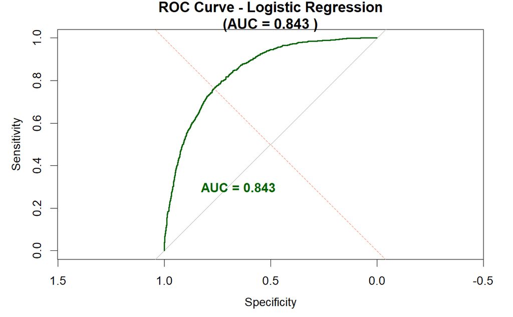

```r
# Annotate the AUC value on the plot
text(0.65, 0.3,
     labels = paste("AUC =", auc_value),
     col = "darkgreen",
     cex = 1.1,
     font = 2)
```

###### **• SeniorCitizen:** Older customers are more likely to leave than younger ones. The company should try to keep them by offering easier plans or special deals just for them.

###### **• Contract (One year / Two year):** Customers with one- or two-year contracts are less likely to leave than those who pay month-to-month. Offering benefits for choosing longer contracts can help keep more customers.

###### **• Payment Method (Electronic Check):** Customers who pay using electronic checks are more likely to leave. To reduce this, the company can offer rewards to encourage them to switch to automatic or credit card payments.

###### **• Multiple Lines (Yes):** Customers who have more than one service line are a bit more likely to leave. To keep them, the company can offer bundle deals or loyalty rewards.

###### **• Internet Service (Fiber Optic):** Customers using fiber optic internet are more likely to leave than those using DSL. The company should check for any problems or dissatisfaction with the fiber service.

###### **• Paperless Billing (Yes):** Customers who use paperless billing are more likely to leave. To help keep them, the company should make sure the online experience is easy to use and consider asking for their feedback.

###### **• Final Takeaway:** The LDA model shows that customers who are new, use fiber optic internet, or pay with flexible or electronic billing options are more likely to leave. Focusing on keeping these groups happy can help improve overall customer loyalty.

###### **Try different thresholds to identify the threshold with the highest prediction accuracy on the test set.**

```r
# Define threshold range for classification
thresholds <- seq(0.4, 0.8, by = 0.01)

# Initialize vector to store accuracy values
accuracy <- numeric(length(thresholds))

# Loop through thresholds to evaluate classification accuracy
for (i in seq_along(thresholds)) {
  # Make predictions based on current threshold
  predicted_status <- ifelse(
    predict(best_logistic_model, newdata = test_data, type = "response") > thresholds[i],
    "Left", "Current"
  )

  # Calculate accuracy at the current threshold
  accuracy[i] <- mean(predicted_status == test_data$Status)
}

# Identify threshold with the highest accuracy
best_threshold <- thresholds[which.max(accuracy)]
best_accuracy <- max(accuracy)

# Output the best threshold and corresponding accuracy
cat("Best AUC:", round(best_auc, 4), "\n")
```

```
Best AUC: 0.843
```

```r
cat("Best Threshold:", best_threshold, "\n")
```

```
Best Threshold: 0.55
```

```r
cat("Best Accuracy:", round(best_accuracy, 4), "\n")
```

```
Best Accuracy: 0.8215
```

#### **Question 3**

##### **Naive Bayes**

###### **Use the training set to build a *Naive Bayes* model to predict the probability for losing a customer.**

```r
# Convert SeniorCitizen to factor
Model_Building_Data$SeniorCitizen <- factor(Model_Building_Data$SeniorCitizen, levels = c(0, 1), labels = c("No", "Yes"))

# Prepare binned variables
nb_data <- Model_Building_Data %>%
  mutate(
    Tenure_binned = factor(ifelse(Tenure < 36, "Short", "Long")),
    TotalCharges_binned = cut(
      TotalCharges,
      breaks = c(-Inf, 2500, 5000, Inf),
      labels = c("Low", "Medium", "High"),
      right = FALSE
    )
  )

# Set seed for reproducibility
set.seed(400)

# Split into training and testing sets (80/20)
train_indices <- sample(seq_len(nrow(nb_data)), size = 0.8 * nrow(nb_data))
nb_train_data <- nb_data[train_indices, ]
nb_test_data  <- nb_data[-train_indices, ]
```

```r
library(e1071)
nb_model <- naiveBayes(Status ~ SeniorCitizen + MultipleLines + InternetService + Contract + PaymentMethod + Tenure_binned +TotalCharges_binned , data = nb_train_data, laplace = 0.01)
nb_model
```

```
Naive Bayes Classifier for Discrete Predictors

Call:
naiveBayes.default(x = X, y = Y, laplace = laplace)

A-priori probabilities:
Y
  Current      Left
0.7351414 0.2648586

Conditional probabilities:
         SeniorCitizen
Y                No       Yes
  Current 0.8689149 0.1310851
  Left    0.7516303 0.2483697

         MultipleLines
Y                 No No phone service        Yes
  Current 0.49057961       0.09890294 0.41051745
  Left    0.45823984       0.09078234 0.45097783

         InternetService
Y                DSL Fiber optic         No
  Current 0.37545754  0.35217149 0.27237097
  Left    0.24401066  0.69425503 0.06173431

         Contract
Y         Month-to-month   One year   Two year
  Current     0.43197201 0.25405609 0.31397189
  Left        0.88960299 0.08424653 0.02615048

         PaymentMethod
Y         Bank transfer (automatic) Credit card (automatic) Electronic check Mailed check
  Current                 0.2498692               0.2448980        0.2517007    0.2535321
  Left                    0.1365320               0.1227343        0.5722492    0.1684846

         Tenure_binned
Y              Long     Short
  Current 0.5188382 0.4811618
  Left    0.1997139 0.8002861

         TotalCharges_binned
Y                Low     Medium       High
  Current 0.60125378 0.21585650 0.18288972
  Left    0.76832749 0.15033078 0.08134173
```

```
Call:
roc.default(response = test_data$Status, predictor = predict(nb_model,     newdata = nb_test_data, type = "raw")[, 1], plot = TRUE,     print.auc = TRUE)

Data: predict(nb_model, newdata = nb_test_data, type = "raw")[, 1] in 946 controls (test_data$Status Current) > 354 cases (test_data$Status Left).
Area under the curve: 0.8387
```

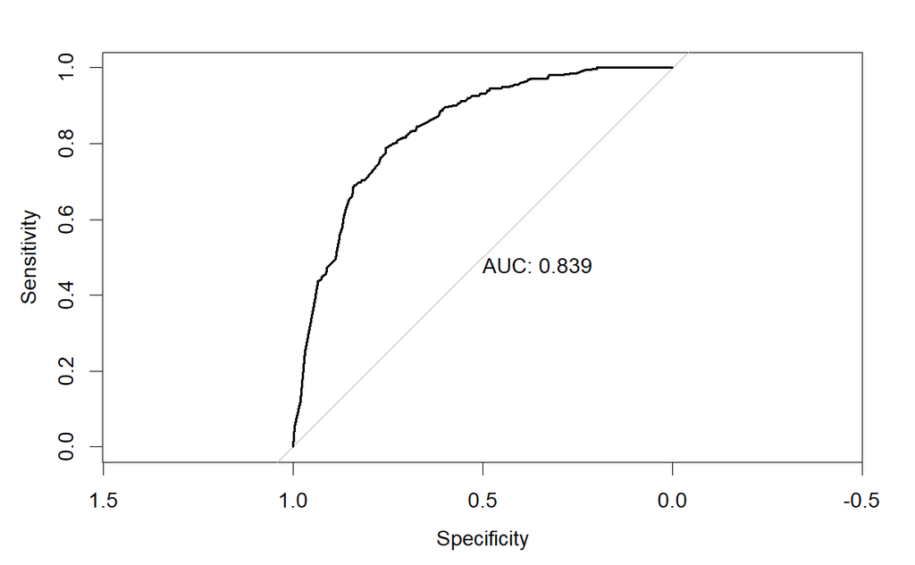

```r
roc(test_data$Status, predict(nb_model, newdata = nb_test_data, type = "raw")[,1],plot=TRUE,print.auc=TRUE)
```

###### **Try different combinations of variables and arrive at the model that maximizes AUC (Area Under the Curve) for the ROC plots.**

```r
# Fit a Naive Bayes model with selected predictors and slight Laplace smoothing
nb_model2 <- naiveBayes(
  Status ~ SeniorCitizen + Contract + PaymentMethod + Tenure_binned + TotalCharges_binned,
  data = nb_train_data,
  laplace = 0.01
)

# Display model summary
print(nb_model2)
```

```
Naive Bayes Classifier for Discrete Predictors

Call:
naiveBayes.default(x = X, y = Y, laplace = laplace)

A-priori probabilities:
Y
  Current      Left
0.7351414 0.2648586

Conditional probabilities:
         SeniorCitizen
Y                No       Yes
  Current 0.8689149 0.1310851
  Left    0.7516303 0.2483697

         Contract
Y         Month-to-month   One year   Two year
  Current     0.43197201 0.25405609 0.31397189
  Left        0.88960299 0.08424653 0.02615048

         PaymentMethod
Y         Bank transfer (automatic) Credit card (automatic) Electronic check Mailed check
  Current                 0.2498692               0.2448980        0.2517007    0.2535321
  Left                    0.1365320               0.1227343        0.5722492    0.1684846

         Tenure_binned
Y              Long     Short
  Current 0.5188382 0.4811618
  Left    0.1997139 0.8002861

         TotalCharges_binned
Y                Low     Medium       High
  Current 0.60125378 0.21585650 0.18288972
  Left    0.76832749 0.15033078 0.08134173
```

```r
roc(test_data$Status, predict(nb_model2, newdata = nb_test_data, type = "raw")[,1],plot=FALSE,print.auc=TRUE)
```

```
Call:
roc.default(response = test_data$Status, predictor = predict(nb_model2,     newdata = nb_test_data, type = "raw")[, 1], plot = FALSE,     print.auc = TRUE)

Data: predict(nb_model2, newdata = nb_test_data, type = "raw")[, 1] in 946 controls (test_data$Status Current) > 354 cases (test_data$Status Left).
Area under the curve: 0.7996
```

###### **For the model with the highest AUC, try different thresholds to identify the threshold with the highest prediction accuracy on the test set.**

```r
# Function to calculate accuracy based on a probability threshold
calculate_accuracy <- function(probabilities, threshold) {
  predicted_status <- ifelse(probabilities >= threshold, "Current", "Left")
  mean(predicted_status == test_data$Status)
}

# Define the thresholds to test
thresholds <- seq(0.3, 0.7, by = 0.01)

# Get predicted probabilities for the "Current" class once
nb_probabilities <- predict(nb_model, test_data, type = "raw")[, "Current"]

# Calculate accuracy for each threshold
accuracy_results <- sapply(thresholds, function(th) calculate_accuracy(nb_probabilities, th))

# Identify the best threshold and accuracy
best_threshold <- thresholds[which.max(accuracy_results)]
best_accuracy <- max(accuracy_results)

# Display results
cat("Best Threshold:", round(best_threshold, 2),
    "| Accuracy:", round(best_accuracy, 4), "\n")
```

```
Best Threshold: 0.3 | Accuracy: 0.79
```

#### **Question 4**

##### **Linear Discriminant Analysis**

###### **Use the training set to build a model using Linear Discriminant Analysis to predict the probability for losing a customer.**

```r
library(MASS)
library(caret)
library(tidyverse)
library(ISLR)
```

```r
lda_model <- lda(Status ~ SeniorCitizen + MultipleLines + InternetService + Contract + PaymentMethod + Tenure +TotalCharges, data = train_data)
lda_model
```

```
Call:
lda(Status ~ SeniorCitizen + MultipleLines + InternetService +
    Contract + PaymentMethod + Tenure + TotalCharges, data = train_data)

Prior probabilities of groups:
  Current      Left
0.7351414 0.2648586

Group means:
        SeniorCitizen1 MultipleLinesNo phone service MultipleLinesYes InternetServiceFiber optic InternetServiceNo ContractOne year ContractTwo year
Current      0.1310832                    0.09890110        0.4105181                  0.3521716         0.2723705        0.2540555       0.31397174
Left         0.2483660                    0.09077705        0.4509804                  0.6942629         0.0617284        0.0842411       0.02614379
        PaymentMethodCredit card (automatic) PaymentMethodElectronic check PaymentMethodMailed check   Tenure TotalCharges
Current                            0.2448980                     0.2517007                 0.2535322 37.42177     2538.153
Left                               0.1227306                     0.5722585                 0.1684822 18.08860     1542.849

Coefficients of linear discriminants:
                                               LD1
SeniorCitizen1                        0.2565882258
MultipleLinesNo phone service         0.2885097710
MultipleLinesYes                      0.2908292417
InternetServiceFiber optic            1.0920527912
InternetServiceNo                    -0.5733341907
ContractOne year                     -0.6514802276
ContractTwo year                     -0.5044200101
PaymentMethodCredit card (automatic) -0.0475710880
PaymentMethodElectronic check         0.4480216944
PaymentMethodMailed check            -0.0785902160
Tenure                               -0.0117471390
TotalCharges                         -0.0001922651
```

###### **Try different combinations of variables and arrive at the model that maximizes AUC (Area Under the Curve) for the ROC plots.**

```
Warning: Deprecated use a matrix as predictor. Unexpected results may be produced, please pass a numeric vector.Setting direction: controls < cases
```

```
Call:
roc.default(response = test_data$Status, predictor = predict(lda_model,     newdata = test_data, type = "raw")$x, plot = TRUE, print.auc = TRUE)

Data: predict(lda_model, newdata = test_data, type = "raw")$x in 946 controls (test_data$Status Current) < 354 cases (test_data$Status Left).
Area under the curve: 0.8565
```

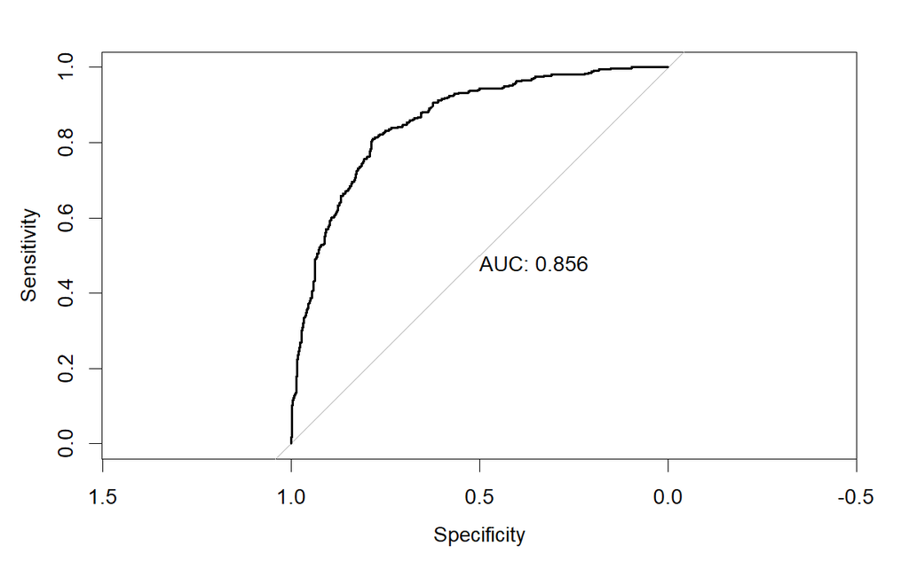

```r
roc(test_data$Status, predict(lda_model, newdata = test_data, type = "raw")$x,plot=TRUE,print.auc=TRUE)
```

```r
lda_modelb <- lda(Status ~ SeniorCitizen  + Contract + PaymentMethod + Tenure +TotalCharges + MultipleLines +InternetService+PaperlessBilling , data = train_data)
```

```r
lda_modelb
```

```
Call:
lda(Status ~ SeniorCitizen + Contract + PaymentMethod + Tenure +
    TotalCharges + MultipleLines + InternetService + PaperlessBilling,
    data = train_data)

Prior probabilities of groups:
  Current      Left
0.7351414 0.2648586

Group means:
        SeniorCitizen1 ContractOne year ContractTwo year PaymentMethodCredit card (automatic) PaymentMethodElectronic check PaymentMethodMailed check   Tenure
Current      0.1310832        0.2540555       0.31397174                            0.2448980                     0.2517007                 0.2535322 37.42177
Left         0.2483660        0.0842411       0.02614379                            0.1227306                     0.5722585                 0.1684822 18.08860
        TotalCharges MultipleLinesNo phone service MultipleLinesYes InternetServiceFiber optic InternetServiceNo PaperlessBillingYes
Current     2538.153                    0.09890110        0.4105181                  0.3521716         0.2723705           0.5347985
Left        1542.849                    0.09077705        0.4509804                  0.6942629         0.0617284           0.7436456

Coefficients of linear discriminants:
                                              LD1
SeniorCitizen1                        0.241754342
ContractOne year                     -0.622556481
ContractTwo year                     -0.462802644
PaymentMethodCredit card (automatic) -0.051622722
PaymentMethodElectronic check         0.433838258
PaymentMethodMailed check            -0.062483462
Tenure                               -0.011818934
TotalCharges                         -0.000194733
MultipleLinesNo phone service         0.276689342
MultipleLinesYes                      0.278940811
InternetServiceFiber optic            1.047481870
InternetServiceNo                    -0.526504407
PaperlessBillingYes                   0.266298461
```

```
Warning: Deprecated use a matrix as predictor. Unexpected results may be produced, please pass a numeric vector.Setting direction: controls < cases
```

```
Call:
roc.default(response = test_data$Status, predictor = predict(lda_model2,     newdata = test_data, type = "raw")$x, plot = TRUE, print.auc = TRUE)

Data: predict(lda_model2, newdata = test_data, type = "raw")$x in 946 controls (test_data$Status Current) < 354 cases (test_data$Status Left).
Area under the curve: 0.8574
```

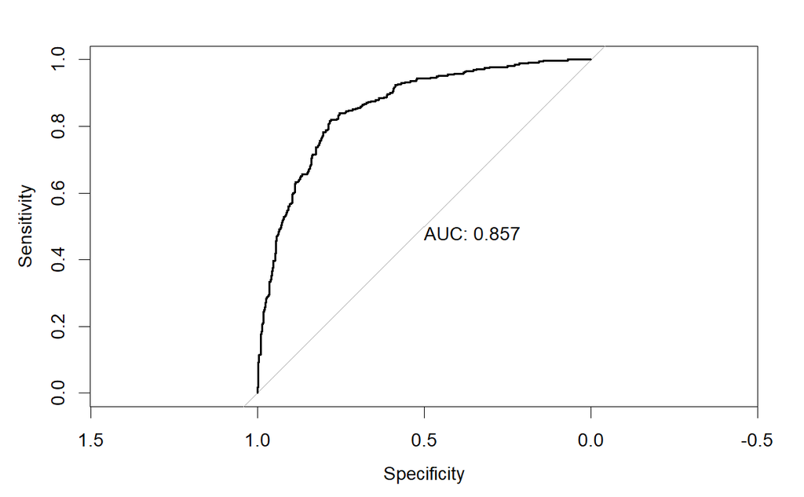

```r
roc(test_data$Status, predict(lda_model2, newdata = test_data, type = "raw")$x,plot=TRUE,print.auc=TRUE)
```

###### **For the model with the highest AUC, try different thresholds to identify the threshold with the highest prediction accuracy on the test set.**

```r
LDA_Predictions_best <- predict(lda_modelb,newdata = test_data)$posterior[,2]
```

```r
# Define a wider range of thresholds to test
thresholds <- seq(0.1, 0.9, by = 0.01)
accuracy_list <- numeric(length(thresholds))  # Vector to store accuracy values

# Evaluate accuracy at each threshold
for (i in seq_along(thresholds)) {
  predicted_status <- ifelse(LDA_Predictions_best > thresholds[i], "Left", "Current")
  predicted_status <- factor(predicted_status, levels = levels(test_data$Status))

  # Create confusion matrix and calculate accuracy
  cm <- table(predicted_status, test_data$Status)
  accuracy_list[i] <- sum(diag(cm)) / sum(cm)
}

# Identify the threshold with the highest accuracy
best_index <- which.max(accuracy_list)
best_threshold <- thresholds[best_index]
best_accuracy <- accuracy_list[best_index]

# Output results
cat("Best Threshold:", round(best_threshold, 2),
    "| Accuracy:", round(best_accuracy, 4), "\n")
```

```
Best Threshold: 0.45 | Accuracy: 0.8154
```

#### **Question 5**

##### **Quadratic Discriminant Analysis**

###### **Use the training set to build a model using *Quadratic Discriminant Analysis* to predict the probability for losing a customer.**

```r
library(caret)

qda_model <- qda(Status ~ SeniorCitizen + Contract + PaymentMethod + Tenure + TotalCharges, data = train_data)
qda_predictions <- predict(qda_model, test_data)$class
qda_predictions <- factor(qda_predictions, levels = levels(test_data$Status))
# Evaluate model performance
confusionMatrix(qda_predictions, test_data$Status, positive = "Current")
```

```
Confusion Matrix and Statistics

          Reference
Prediction Current Left
   Current     649   59
   Left        297  295

               Accuracy : 0.7262
                 95% CI : (0.701, 0.7502)
    No Information Rate : 0.7277
    P-Value [Acc > NIR] : 0.5637

                  Kappa : 0.4291

 Mcnemar's Test P-Value : <2e-16

            Sensitivity : 0.6860
            Specificity : 0.8333
         Pos Pred Value : 0.9167
         Neg Pred Value : 0.4983
             Prevalence : 0.7277
         Detection Rate : 0.4992
   Detection Prevalence : 0.5446
      Balanced Accuracy : 0.7597

       'Positive' Class : Current
```

###### **Try different combinations of variables and arrive at the model that maximizes AUC (Area Under the Curve) for the ROC plots.**

```
Call:
roc.default(response = test_data$Status, predictor = predict(qda_model,     newdata = test_data, type = "raw")[["posterior"]][, 2], plot = TRUE,     print.auc = TRUE)

Data: predict(qda_model, newdata = test_data, type = "raw")[["posterior"]][, 2] in 946 controls (test_data$Status Current) < 354 cases (test_data$Status Left).
Area under the curve: 0.8377
```

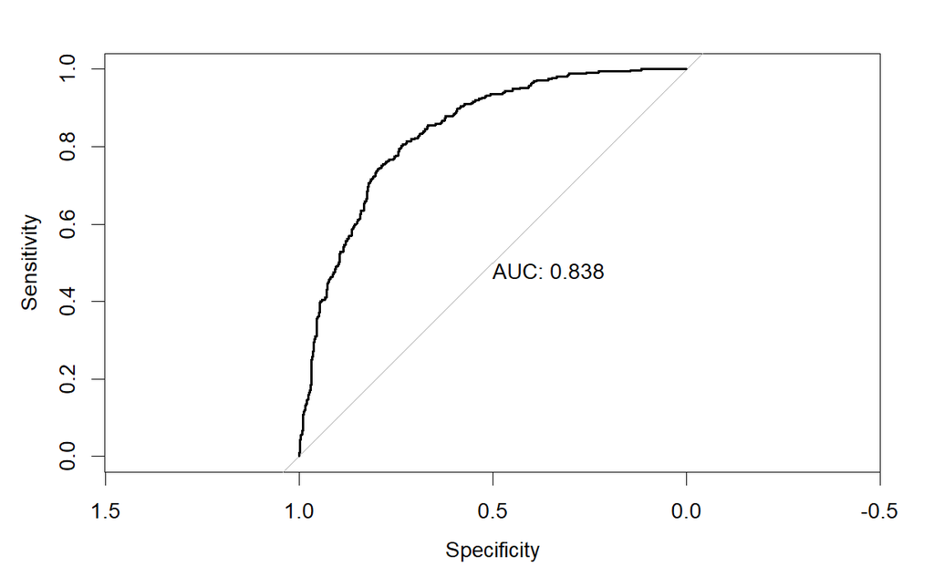

```r
roc(test_data$Status, predict(qda_model, newdata = test_data, type = "raw")[["posterior"]][,2],plot=TRUE,print.auc=TRUE)
```

```r
# Train QDA model using selected predictors
qda_model2 <- qda(
  Status ~ SeniorCitizen + Contract + PaymentMethod + Tenure +
    TotalCharges + MultipleLines + InternetService + PaperlessBilling,
  data = train_data
)
print(qda_model2)
```

```
Call:
qda(Status ~ SeniorCitizen + Contract + PaymentMethod + Tenure +
    TotalCharges + MultipleLines + InternetService + PaperlessBilling,
    data = train_data)

Prior probabilities of groups:
  Current      Left
0.7351414 0.2648586

Group means:
        SeniorCitizen1 ContractOne year ContractTwo year PaymentMethodCredit card (automatic) PaymentMethodElectronic check PaymentMethodMailed check   Tenure
Current      0.1310832        0.2540555       0.31397174                            0.2448980                     0.2517007                 0.2535322 37.42177
Left         0.2483660        0.0842411       0.02614379                            0.1227306                     0.5722585                 0.1684822 18.08860
        TotalCharges MultipleLinesNo phone service MultipleLinesYes InternetServiceFiber optic InternetServiceNo PaperlessBillingYes
Current     2538.153                    0.09890110        0.4105181                  0.3521716         0.2723705           0.5347985
Left        1542.849                    0.09077705        0.4509804                  0.6942629         0.0617284           0.7436456
```

```r
tree_model <- tree(Status ~ ., data = train_data)
str(tree_model)
```

```
List of 6
 $ frame  :'data.frame':    11 obs. of  6 variables:
  ..$ var   : Factor w/ 17 levels "<leaf>","Gender",..: 13 12 1 1 9 6 1 1 6 1 ...
  ..$ n     : num [1:11] 5199 2323 1273 1050 2876 ...
  ..$ dev   : num [1:11] 6011 1123 299 746 3924 ...
  ..$ yval  : Factor w/ 2 levels "Current","Left": 1 1 1 1 1 1 1 1 2 2 ...
  ..$ splits: chr [1:11, 1:2] ":bc" ":ab" "" "" ...
  .. ..- attr(*, "dimnames")=List of 2
  .. .. ..$ : NULL
  .. .. ..$ : chr [1:2] "cutleft" "cutright"
  ..$ yprob : num [1:11, 1:2] 0.735 0.935 0.975 0.886 0.574 ...
  .. ..- attr(*, "dimnames")=List of 2
  .. .. ..$ : NULL
  .. .. ..$ : chr [1:2] "Current" "Left"
 $ where  : Named int [1:5199] 4 11 11 8 3 11 8 4 3 4 ...
  ..- attr(*, "names")= chr [1:5199] "1768" "4265" "3865" "1895" ...
 $ terms  :Classes 'terms', 'formula'  language Status ~ Gender + SeniorCitizen + Partner + Dependents + Tenure + PhoneService + MultipleLines + InternetService | __truncated__
  .. ..- attr(*, "variables")= language list(Status, Gender, SeniorCitizen, Partner, Dependents, Tenure, PhoneService, MultipleLines, InternetService, On| __truncated__
  .. ..- attr(*, "factors")= int [1:17, 1:16] 0 1 0 0 0 0 0 0 0 0 ...
  .. .. ..- attr(*, "dimnames")=List of 2
  .. .. .. ..$ : chr [1:17] "Status" "Gender" "SeniorCitizen" "Partner" ...
  .. .. .. ..$ : chr [1:16] "Gender" "SeniorCitizen" "Partner" "Dependents" ...
  .. ..- attr(*, "term.labels")= chr [1:16] "Gender" "SeniorCitizen" "Partner" "Dependents" ...
  .. ..- attr(*, "order")= int [1:16] 1 1 1 1 1 1 1 1 1 1 ...
  .. ..- attr(*, "intercept")= int 1
  .. ..- attr(*, "response")= int 1
  .. ..- attr(*, ".Environment")=<environment: R_GlobalEnv>
  .. ..- attr(*, "predvars")= language list(Status, Gender, SeniorCitizen, Partner, Dependents, Tenure, PhoneService, MultipleLines, InternetService, On| __truncated__
  .. ..- attr(*, "dataClasses")= Named chr [1:17] "factor" "factor" "factor" "factor" ...
  .. .. ..- attr(*, "names")= chr [1:17] "Status" "Gender" "SeniorCitizen" "Partner" ...
 $ call   : language tree(formula = Status ~ ., data = train_data)
 $ y      : Factor w/ 2 levels "Current","Left": 1 1 2 1 1 2 2 1 1 1 ...
  ..- attr(*, "names")= chr [1:5199] "1768" "4265" "3865" "1895" ...
 $ weights: num [1:5199] 1 1 1 1 1 1 1 1 1 1 ...
 - attr(*, "class")= chr "tree"
 - attr(*, "xlevels")=List of 16
  ..$ Gender          : chr [1:2] "Female" "Male"
  ..$ SeniorCitizen   : chr [1:2] "0" "1"
  ..$ Partner         : chr [1:2] "No" "Yes"
  ..$ Dependents      : chr [1:2] "No" "Yes"
  ..$ Tenure          : NULL
  ..$ PhoneService    : chr [1:2] "No" "Yes"
  ..$ MultipleLines   : chr [1:3] "No" "No phone service" "Yes"
  ..$ InternetService : chr [1:3] "DSL" "Fiber optic" "No"
  ..$ OnlineSecurity  : chr [1:3] "No" "No internet service" "Yes"
  ..$ DeviceProtection: chr [1:3] "No" "No internet service" "Yes"
  ..$ StreamingMovies : chr [1:3] "No" "No internet service" "Yes"
  ..$ Contract        : chr [1:3] "Month-to-month" "One year" "Two year"
  ..$ PaperlessBilling: chr [1:2] "No" "Yes"
  ..$ PaymentMethod   : chr [1:4] "Bank transfer (automatic)" "Credit card (automatic)" "Electronic check" "Mailed check"
  ..$ MonthlyCharges  : NULL
  ..$ TotalCharges    : NULL
 - attr(*, "ylevels")= chr [1:2] "Current" "Left"
```

```r
# Load the MASS package for QDA
library(MASS)

# Predict posterior probabilities for the "Left" class
QDA_Predictions_best <- predict(qda_model2, newdata = test_data)$posterior[, "Left"]
```

```r
thresholds <- seq(0.1, 0.9, by = 0.01)
accuracy_list <- numeric(length(thresholds))

for (i in seq_along(thresholds)) {
  predicted_status <- ifelse(QDA_Predictions_best > thresholds[i], "Left", "Current")
  predicted_status <- factor(predicted_status, levels = levels(test_data$Status))

  # Compute confusion matrix and accuracy
  cm <- table(predicted_status, test_data$Status)
  accuracy_list[i] <- sum(diag(cm)) / sum(cm)
}

# Find best threshold and corresponding accuracy
best_index <- which.max(accuracy_list)
best_threshold <- thresholds[best_index]
best_accuracy <- accuracy_list[best_index]

cat("Best Threshold:", round(best_threshold, 2),
    "| Accuracy:", round(best_accuracy, 4), "\n")
```

```
Best Threshold: 0.9 | Accuracy: 0.8146
```

#### **Question 6**

##### **Decision Trees**

###### **Use the training set to build a *Decision Tree* model to predict the probability for losing a customer.**

```r
library(tree)

tree_model2 <- tree(
  Status ~ SeniorCitizen + Contract + PaymentMethod + Tenure + TotalCharges +
    MultipleLines + InternetService + PaperlessBilling,
  data = train_data
)
```

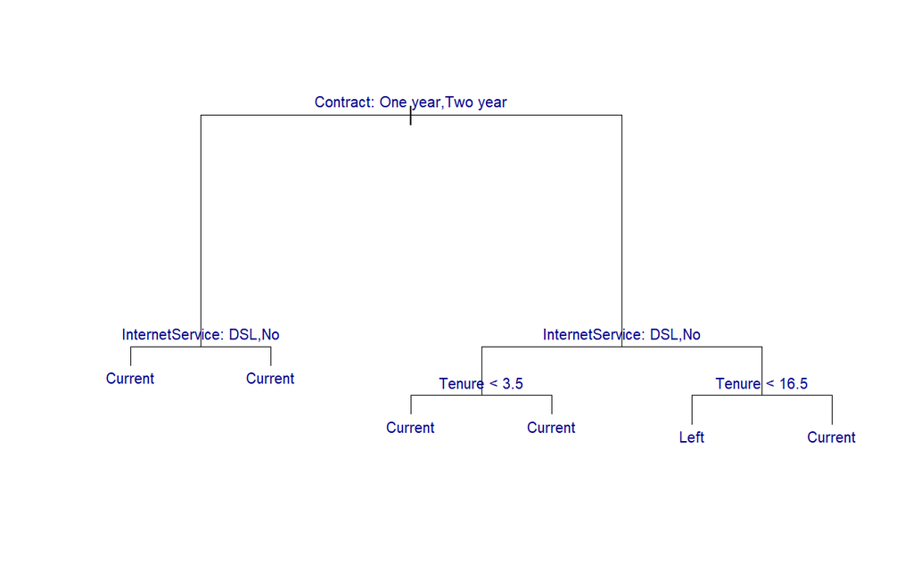

```r
# Plot the decision tree with black branches
plot(tree_model2,
     main = "Decision Tree for Customer Status",
     col = "black")  # Sets the color of the tree branches

# Add text labels to the nodes
text(tree_model2,
     pretty = 0,
     cex = 0.7,
     col = "darkblue")  # Sets label color
```

```r
set.seed(400)
cv.tree2 <- cv.tree(tree_model2, FUN = prune.misclass)
str(cv.tree2)
```

```
List of 4
 $ size  : int [1:3] 6 4 1
 $ dev   : num [1:3] 1094 1094 1377
 $ k     : num [1:3] -Inf 0 94.3
 $ method: chr "misclass"
 - attr(*, "class")= chr [1:2] "prune" "tree.sequence"
```

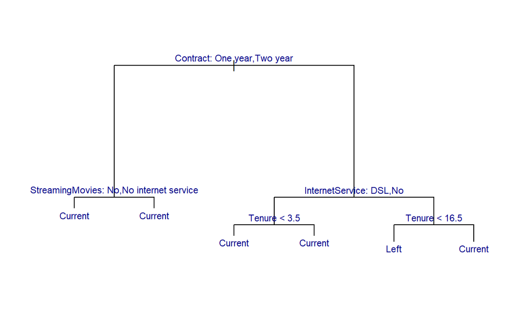

```r
# Plot the decision tree with enhanced visual styling
plot(tree_model,
     main = "Decision Tree for Customer Churn",
     col = "black",
     lty = 1,
     lwd = 1.5)

# Add text labels to the tree nodes
text(tree_model,
     pretty = 0,
     cex = 0.8,
     col = "darkblue")
```

```r
set.seed(400)
cv.tree <- cv.tree(tree_model, FUN = prune.misclass)
str(cv.tree)
```

```
List of 4
 $ size  : int [1:3] 6 4 1
 $ dev   : num [1:3] 1094 1094 1377
 $ k     : num [1:3] -Inf 0 94.3
 $ method: chr "misclass"
 - attr(*, "class")= chr [1:2] "prune" "tree.sequence"
```

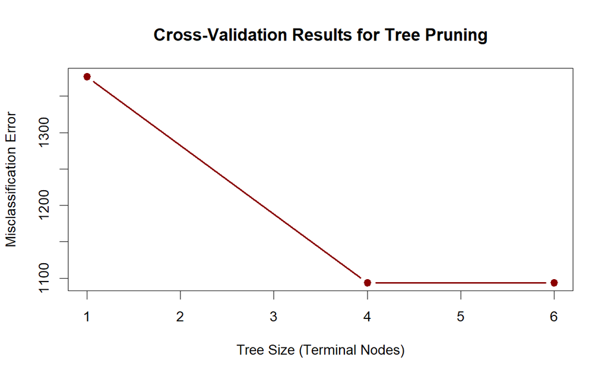

```r
# Plot tree size vs. misclassification error from cross-validation
plot(cv.tree$size, cv.tree$dev,
     type = "b",
     col = "darkred",
     pch = 19,
     lwd = 2,
     xlab = "Tree Size (Terminal Nodes)",
     ylab = "Misclassification Error",
     main = "Cross-Validation Results for Tree Pruning")
```

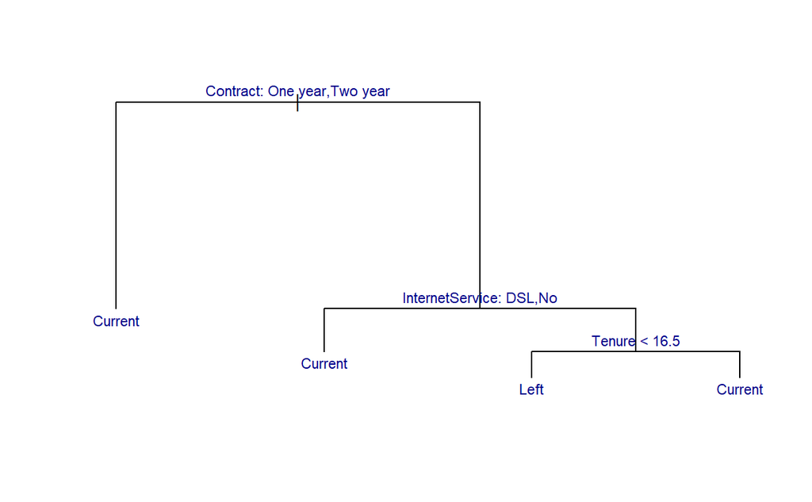

```r
tree_pruned <- prune.misclass(tree_model, best = 4)

plot(tree_pruned,
     main = "Pruned Decision Tree (4 Terminal Nodes)",
     col = "black",
     lwd = 1.5)

text(tree_pruned,
     pretty = 0,
     cex = 0.8,
     col = "darkblue")
```

```r
# Make predictions using the pruned tree
prediction <- predict(tree_pruned, test_data, type = "class")

# Create a confusion matrix
table(prediction, test_data$Status)
```

```
prediction Current Left
   Current     884  207
   Left         62  147
```

```r
library(caret)

prediction <- factor(predict(tree_pruned, test_data, type = "class"),
                     levels = levels(test_data$Status))

confusionMatrix(prediction, test_data$Status, positive = "Current")
```

```
Confusion Matrix and Statistics

          Reference
Prediction Current Left
   Current     884  207
   Left         62  147

               Accuracy : 0.7931
                 95% CI : (0.77, 0.8148)
    No Information Rate : 0.7277
    P-Value [Acc > NIR] : 3.139e-08

                  Kappa : 0.4011

 Mcnemar's Test P-Value : < 2.2e-16

            Sensitivity : 0.9345
            Specificity : 0.4153
         Pos Pred Value : 0.8103
         Neg Pred Value : 0.7033
             Prevalence : 0.7277
         Detection Rate : 0.6800
   Detection Prevalence : 0.8392
      Balanced Accuracy : 0.6749

       'Positive' Class : Current
```

###### Prediction Accuracy for the decision tree is 79.31%

###### **Try different combinations of variables and identify the model with the largest prediction accuracy.**

```r
tree_model2 <- tree(Status ~ Tenure +TotalCharges + MonthlyCharges+Contract, data = train_data)
str(tree_model2)
```

```
List of 6
 $ frame  :'data.frame':    11 obs. of  6 variables:
  ..$ var   : Factor w/ 5 levels "<leaf>","Tenure",..: 5 4 1 1 4 2 1 1 2 1 ...
  ..$ n     : num [1:11] 5199 2323 814 1509 2876 ...
  ..$ dev   : num [1:11] 6011 1123 108 941 3924 ...
  ..$ yval  : Factor w/ 2 levels "Current","Left": 1 1 1 1 1 1 1 1 2 2 ...
  ..$ splits: chr [1:11, 1:2] ":bc" "<41.375" "" "" ...
  .. ..- attr(*, "dimnames")=List of 2
  .. .. ..$ : NULL
  .. .. ..$ : chr [1:2] "cutleft" "cutright"
  ..$ yprob : num [1:11, 1:2] 0.735 0.935 0.988 0.906 0.574 ...
  .. ..- attr(*, "dimnames")=List of 2
  .. .. ..$ : NULL
  .. .. ..$ : chr [1:2] "Current" "Left"
 $ where  : Named int [1:5199] 4 11 11 8 3 11 8 4 3 4 ...
  ..- attr(*, "names")= chr [1:5199] "1768" "4265" "3865" "1895" ...
 $ terms  :Classes 'terms', 'formula'  language Status ~ Tenure + TotalCharges + MonthlyCharges + Contract
  .. ..- attr(*, "variables")= language list(Status, Tenure, TotalCharges, MonthlyCharges, Contract)
  .. ..- attr(*, "factors")= int [1:5, 1:4] 0 1 0 0 0 0 0 1 0 0 ...
  .. .. ..- attr(*, "dimnames")=List of 2
  .. .. .. ..$ : chr [1:5] "Status" "Tenure" "TotalCharges" "MonthlyCharges" ...
  .. .. .. ..$ : chr [1:4] "Tenure" "TotalCharges" "MonthlyCharges" "Contract"
  .. ..- attr(*, "term.labels")= chr [1:4] "Tenure" "TotalCharges" "MonthlyCharges" "Contract"
  .. ..- attr(*, "order")= int [1:4] 1 1 1 1
  .. ..- attr(*, "intercept")= int 1
  .. ..- attr(*, "response")= int 1
  .. ..- attr(*, ".Environment")=<environment: R_GlobalEnv>
  .. ..- attr(*, "predvars")= language list(Status, Tenure, TotalCharges, MonthlyCharges, Contract)
  .. ..- attr(*, "dataClasses")= Named chr [1:5] "factor" "numeric" "numeric" "numeric" ...
  .. .. ..- attr(*, "names")= chr [1:5] "Status" "Tenure" "TotalCharges" "MonthlyCharges" ...
 $ call   : language tree(formula = Status ~ Tenure + TotalCharges + MonthlyCharges + Contract, data = train_data)
 $ y      : Factor w/ 2 levels "Current","Left": 1 1 2 1 1 2 2 1 1 1 ...
  ..- attr(*, "names")= chr [1:5199] "1768" "4265" "3865" "1895" ...
 $ weights: num [1:5199] 1 1 1 1 1 1 1 1 1 1 ...
 - attr(*, "class")= chr "tree"
 - attr(*, "xlevels")=List of 4
  ..$ Tenure        : NULL
  ..$ TotalCharges  : NULL
  ..$ MonthlyCharges: NULL
  ..$ Contract      : chr [1:3] "Month-to-month" "One year" "Two year"
 - attr(*, "ylevels")= chr [1:2] "Current" "Left"
```

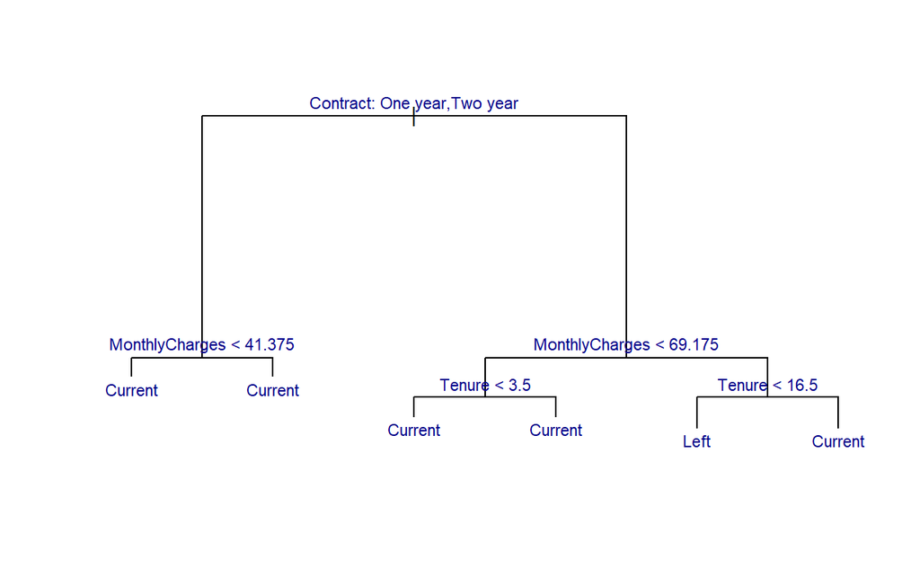

```r
plot(tree_model2,
     main = "Decision Tree for Customer Status (Full Model)",
     col = "black",
     lwd = 1.5)

# Add node labels
text(tree_model2,
     pretty = 0,
     cex = 0.8,
     col = "darkblue")
```

```r
set.seed(400)
cv.tree2 <- cv.tree(tree_model2, FUN = prune.misclass)
str(cv.tree2)
```

```
List of 4
 $ size  : int [1:3] 6 4 1
 $ dev   : num [1:3] 1132 1132 1377
 $ k     : num [1:3] -Inf 0 87.7
 $ method: chr "misclass"
 - attr(*, "class")= chr [1:2] "prune" "tree.sequence"
```

[figure not shown]

```r
plot(cv_tree2$size, cv_tree2$dev,
     type = "b",
     pch = 19,
     col = "darkred",
     lwd = 2,
     xlab = "Tree Size (Number of Terminal Nodes)",
     ylab = "Misclassification Error",
     main = "Cross-Validation for Pruning (tree_model2)")
```

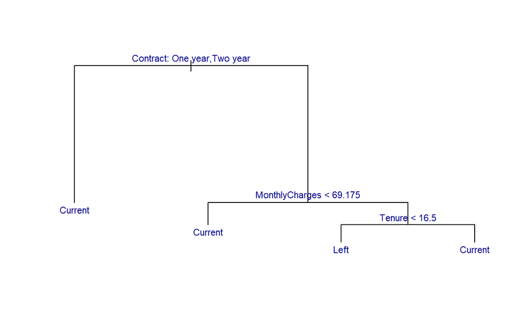

```r
tree_pruned2 <- prune.misclass(tree_model2, best = 4)

plot(tree_pruned2,
     main = "Pruned Decision Tree (4 Terminal Nodes)",
     col = "black",
     lwd = 1.5)

text(tree_pruned2,
     pretty = 0,
     cex = 0.8,
     col = "darkblue")
```

```r
# Generate predictions from the pruned tree
prediction2 <- predict(tree_pruned2, test_data, type = "class")

# Ensure predicted classes have the same levels as the actual Status
prediction2 <- factor(prediction2, levels = levels(test_data$Status))

# Display confusion matrix
table(prediction2, test_data$Status)
```

```
prediction2 Current Left
    Current     878  210
    Left         68  144
```

```r
library(caret)

confusionMatrix(prediction2, test_data$Status, positive = "Current")
```

```
Confusion Matrix and Statistics

          Reference
Prediction Current Left
   Current     878  210
   Left         68  144

               Accuracy : 0.7862
                 95% CI : (0.7628, 0.8082)
    No Information Rate : 0.7277
    P-Value [Acc > NIR] : 7.266e-07

                  Kappa : 0.383

 Mcnemar's Test P-Value : < 2.2e-16

            Sensitivity : 0.9281
            Specificity : 0.4068
         Pos Pred Value : 0.8070
         Neg Pred Value : 0.6792
             Prevalence : 0.7277
         Detection Rate : 0.6754
   Detection Prevalence : 0.8369
      Balanced Accuracy : 0.6674

       'Positive' Class : Current
```

###### The prediction accuracy is 78.62%

```r
tree_model3 <- tree(Status ~ Tenure +InternetService+Contract, data = train_data)
str(tree_model3)
```

```
List of 6
 $ frame  :'data.frame':    11 obs. of  6 variables:
  ..$ var   : Factor w/ 4 levels "<leaf>","Tenure",..: 4 3 1 1 3 2 1 1 2 1 ...
  ..$ n     : num [1:11] 5199 2323 1605 718 2876 ...
  ..$ dev   : num [1:11] 6011 1123 479 569 3924 ...
  ..$ yval  : Factor w/ 2 levels "Current","Left": 1 1 1 1 1 1 1 1 2 2 ...
  ..$ splits: chr [1:11, 1:2] ":bc" ":ac" "" "" ...
  .. ..- attr(*, "dimnames")=List of 2
  .. .. ..$ : NULL
  .. .. ..$ : chr [1:2] "cutleft" "cutright"
  ..$ yprob : num [1:11, 1:2] 0.735 0.935 0.966 0.865 0.574 ...
  .. ..- attr(*, "dimnames")=List of 2
  .. .. ..$ : NULL
  .. .. ..$ : chr [1:2] "Current" "Left"
 $ where  : Named int [1:5199] 4 11 11 8 3 11 8 3 3 4 ...
  ..- attr(*, "names")= chr [1:5199] "1768" "4265" "3865" "1895" ...
 $ terms  :Classes 'terms', 'formula'  language Status ~ Tenure + InternetService + Contract
  .. ..- attr(*, "variables")= language list(Status, Tenure, InternetService, Contract)
  .. ..- attr(*, "factors")= int [1:4, 1:3] 0 1 0 0 0 0 1 0 0 0 ...
  .. .. ..- attr(*, "dimnames")=List of 2
  .. .. .. ..$ : chr [1:4] "Status" "Tenure" "InternetService" "Contract"
  .. .. .. ..$ : chr [1:3] "Tenure" "InternetService" "Contract"
  .. ..- attr(*, "term.labels")= chr [1:3] "Tenure" "InternetService" "Contract"
  .. ..- attr(*, "order")= int [1:3] 1 1 1
  .. ..- attr(*, "intercept")= int 1
  .. ..- attr(*, "response")= int 1
  .. ..- attr(*, ".Environment")=<environment: R_GlobalEnv>
  .. ..- attr(*, "predvars")= language list(Status, Tenure, InternetService, Contract)
  .. ..- attr(*, "dataClasses")= Named chr [1:4] "factor" "numeric" "factor" "factor"
  .. .. ..- attr(*, "names")= chr [1:4] "Status" "Tenure" "InternetService" "Contract"
 $ call   : language tree(formula = Status ~ Tenure + InternetService + Contract, data = train_data)
 $ y      : Factor w/ 2 levels "Current","Left": 1 1 2 1 1 2 2 1 1 1 ...
  ..- attr(*, "names")= chr [1:5199] "1768" "4265" "3865" "1895" ...
 $ weights: num [1:5199] 1 1 1 1 1 1 1 1 1 1 ...
 - attr(*, "class")= chr "tree"
 - attr(*, "xlevels")=List of 3
  ..$ Tenure         : NULL
  ..$ InternetService: chr [1:3] "DSL" "Fiber optic" "No"
  ..$ Contract       : chr [1:3] "Month-to-month" "One year" "Two year"
 - attr(*, "ylevels")= chr [1:2] "Current" "Left"
```

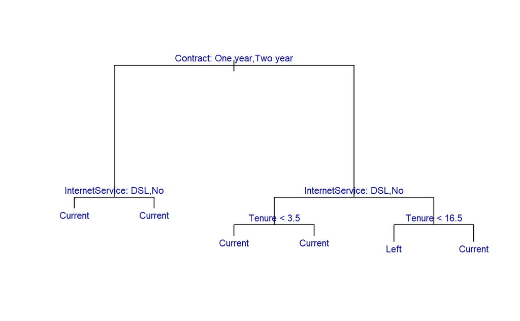

```r
plot(tree_model3,
     main = "Decision Tree for Customer Status (Model 3)",
     col = "black",     # Dark tree branches
     lwd = 1.5)         # Slightly thicker lines

text(tree_model3,
     pretty = 0,        # Show full factor names
     cex = 0.8,         # Adjust label size
     col = "darkblue")      # Label color
```

```r
load("Implementation_Data.rda")
impdata <- Implementation_Data
head(impdata)
```

|  | Gender | SeniorCitizen | Partner | Dependents | Tenure | PhoneService | MultipleLines | InternetService | OnlineSecurity | DeviceProtection | StreamingMovies | Contract | PaperlessBilling | PaymentMethod | MonthlyCharges | TotalCharges |
| --- | --- | --- | --- | --- | --- | --- | --- | --- | --- | --- | --- | --- | --- | --- | --- | --- |
| 5686 | Male | 0 | Yes | Yes | 45 | Yes | No | No | No internet service | No internet service | No internet service | Two year | No | Electronic check | 19.20 | 903.7 |
| 4292 | Female | 0 | Yes | Yes | 64 | Yes | Yes | Fiber optic | Yes | No | Yes | Two year | No | Bank transfer (automatic) | 110.30 | 6997.3 |
| 1865 | Female | 1 | Yes | No | 26 | Yes | No | DSL | No | Yes | Yes | One year | No | Mailed check | 60.70 | 1597.4 |
| 1010 | Male | 1 | Yes | No | 23 | Yes | No | No | No internet service | No internet service | No internet service | One year | Yes | Electronic check | 20.75 | 485.2 |
| 882 | Male | 1 | No | No | 26 | Yes | No | No | No internet service | No internet service | No internet service | One year | No | Credit card (automatic) | 19.30 | 504.2 |
| 853 | Male | 0 | No | No | 2 | Yes | Yes | No | No internet service | No internet service | No internet service | Month-to-month | No | Mailed check | 24.85 | 62.0 |

```r
set.seed(400)
cv.tree3 <- cv.tree(tree_model3, FUN = prune.misclass)
```

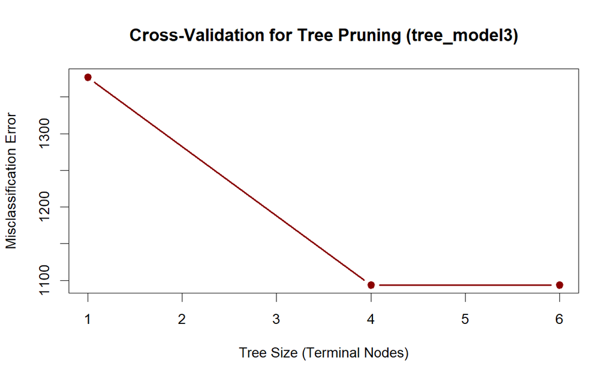

```r
plot(cv.tree3$size, cv.tree3$dev,
     type = "b",
     pch = 19,
     col = "darkred",
     lwd = 2,
     xlab = "Tree Size (Terminal Nodes)",
     ylab = "Misclassification Error",
     main = "Cross-Validation for Tree Pruning (tree_model3)")
```

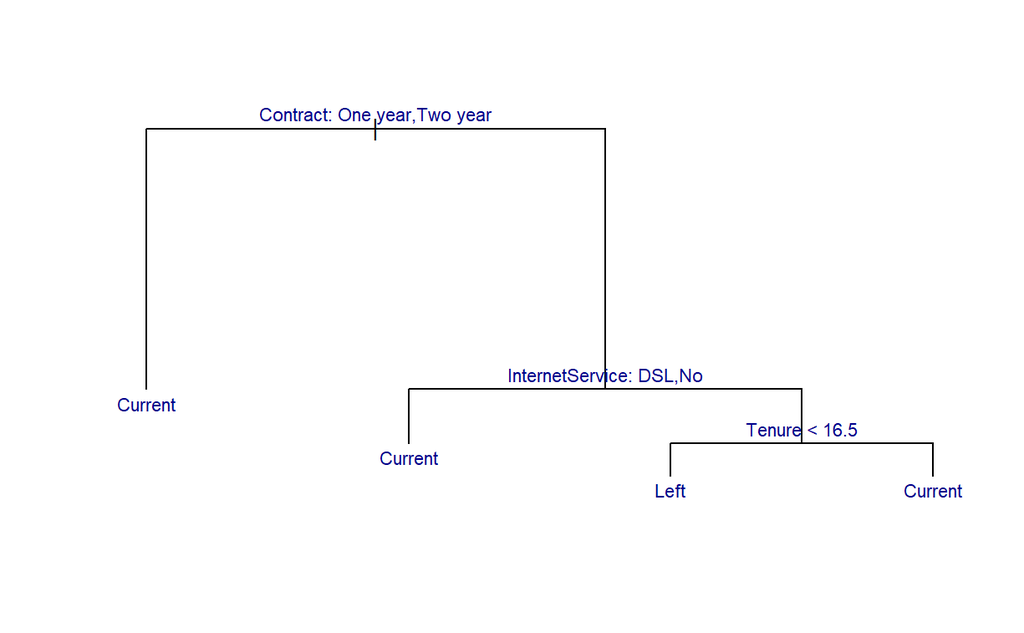

```r
tree_pruned3 <- prune.misclass(tree_model3, best = 4)

plot(tree_pruned3,
     main = "Pruned Decision Tree (4 Terminal Nodes)",
     col = "black",
     lwd = 1.5)

text(tree_pruned3,
     pretty = 0,
     cex = 0.8,
     col = "darkblue")
```

```r
prediction3 <- predict(tree_pruned3, test_data, type = "class")
prediction3 <- factor(prediction3, levels = levels(test_data$Status))

table(prediction3, test_data$Status)
```

```
prediction3 Current Left
    Current     884  207
    Left         62  147
```

```r
confusionMatrix(prediction3, test_data$Status, positive = "Current")
```

```
Confusion Matrix and Statistics

          Reference
Prediction Current Left
   Current     884  207
   Left         62  147

               Accuracy : 0.7931
                 95% CI : (0.77, 0.8148)
    No Information Rate : 0.7277
    P-Value [Acc > NIR] : 3.139e-08

                  Kappa : 0.4011

 Mcnemar's Test P-Value : < 2.2e-16

            Sensitivity : 0.9345
            Specificity : 0.4153
         Pos Pred Value : 0.8103
         Neg Pred Value : 0.7033
             Prevalence : 0.7277
         Detection Rate : 0.6800
   Detection Prevalence : 0.8392
      Balanced Accuracy : 0.6749

       'Positive' Class : Current
```